# Fake_News_code

## Fake News Analysis

import all necessary libraries needed

```python
import pandas as pd
import numpy as np
import os
import pyrsm as rsm
import pickle
import itertools
import string
import seaborn as sns
import matplotlib as mpl
import matplotlib.pyplot as plt
from wordcloud import WordCloud, STOPWORDS
from matplotlib import pyplot
from collections import Counter
from nltk import word_tokenize
from nltk.corpus import stopwords
from gensim.models import word2vec
from vaderSentiment.vaderSentiment import SentimentIntensityAnalyzer
import statsmodels.api as sm
import statsmodels.formula.api as smf
from statsmodels.genmod.families import Binomial
from statsmodels.genmod.families.links import logit
from sklearn.model_selection import train_test_split
from sklearn.linear_model import LogisticRegressionCV
from sklearn.linear_model import LogisticRegression
from sklearn.metrics import accuracy_score
from sklearn.tree import DecisionTreeClassifier
from sklearn.neural_network import MLPClassifier
from sklearn.metrics import accuracy_score
from sklearn.metrics import classification_report, confusion_matrix
from tqdm import tqdm
```

Read CSV files

```python
fake_df = pd.read_csv('Fake.csv')
fake_df.head()
```

|  | title | text | subject | date |
| --- | --- | --- | --- | --- |
| 0 | Donald Trump Sends Out Embarrassing New Year’... | Donald Trump just couldn t wish all Americans ... | News | December 31, 2017 |
| 1 | Drunk Bragging Trump Staffer Started Russian ... | House Intelligence Committee Chairman Devin Nu... | News | December 31, 2017 |
| 2 | Sheriff David Clarke Becomes An Internet Joke... | On Friday, it was revealed that former Milwauk... | News | December 30, 2017 |
| 3 | Trump Is So Obsessed He Even Has Obama’s Name... | On Christmas day, Donald Trump announced that ... | News | December 29, 2017 |
| 4 | Pope Francis Just Called Out Donald Trump Dur... | Pope Francis used his annual Christmas Day mes... | News | December 25, 2017 |

```python
true_df = pd.read_csv('True.csv')
true_df.head()
```

|  | title | text | subject | date |
| --- | --- | --- | --- | --- |
| 0 | As U.S. budget fight looms, Republicans flip t... | WASHINGTON (Reuters) - The head of a conservat... | politicsNews | December 31, 2017 |
| 1 | U.S. military to accept transgender recruits o... | WASHINGTON (Reuters) - Transgender people will... | politicsNews | December 29, 2017 |
| 2 | Senior U.S. Republican senator: 'Let Mr. Muell... | WASHINGTON (Reuters) - The special counsel inv... | politicsNews | December 31, 2017 |
| 3 | FBI Russia probe helped by Australian diplomat... | WASHINGTON (Reuters) - Trump campaign adviser ... | politicsNews | December 30, 2017 |
| 4 | Trump wants Postal Service to charge 'much mor... | SEATTLE/WASHINGTON (Reuters) - President Donal... | politicsNews | December 29, 2017 |

```python
print("Length of fake news dataframe: ", len(fake_df))
print("Length of true news dataframe: ", len(true_df))
```

```
Length of fake news dataframe:  23481
Length of true news dataframe:  21417
```

Add a column `isTrue` to each dataframe. If true then assign 1, if fake then assign 0

```python
fake_df["isTrue"] = 0
true_df["isTrue"] = 1
```

Concat 2 dataframes into 1 "news" dataframe for analysis

```python
news = pd.concat([fake_df, true_df], ignore_index=True)
print("Length of the whole news dataframe: ", len(news))
```

```
Length of the whole news dataframe:  44898
```

### Exploratory Data Analysis

There's empty text in few of the news.

```python
news.iloc[12658:12663, :]
```

|  | title | text | subject | date | isTrue |
| --- | --- | --- | --- | --- | --- |
| 12658 | ANTI-HILLARY POSTERS POP UP All Over Hollywood... | The first time I heard Negan ask for 50 perc... | politics | Oct 22, 2016 | 0 |
| 12659 | DONALD TRUMP’S SEVEN ACTIONS To Protect Americ... |  | politics | Oct 22, 2016 | 0 |
| 12660 | TOP POLLSTER WARNS Something Strange Going On ... | All of the tracking polls keep holding at Tru... | politics | Oct 22, 2016 | 0 |
| 12661 | DINESH D’SOUZA Has A Brilliant Message For ALL... |  | politics | Oct 22, 2016 | 0 |
| 12662 | LIVE STREAM: DONALD TRUMP -FIRST 100 DAYS SPEE... |  | politics | Oct 22, 2016 | 0 |

```python
print("There are", sum(news.text == ' ') + sum(news.text == '  '), "rows of data that have only title but empty text")
```

```
There are 631 rows of data that have only title but empty text
```

Row 18933 also contains unreasonable text message

```python
news.iloc[18933, :]
```

```
title                                               Homepage
text       [vc_row][vc_column width= 1/1 ][td_block_trend...
subject                                            left-news
date       MSNBC HOST Rudely Assumes Steel Worker Would N...
isTrue                                                     0
Name: 18933, dtype: object
```

We'll drop the rows that contain empty text and unreasonable texts

```python
index_empty_text = news[(news.text == ' ') | (news.text == '  ')].index
news = news.drop(index_empty_text).reset_index(drop=True)
news = news.drop(18933).reset_index(drop=True)
```

```python
print("Length of the whole news dataframe: ", len(news))
print("Counts of fake news: ", len(news.query("isTrue==0")))
print("Counts of true news: ", len(news.query("isTrue==1")))
```

```
Length of the whole news dataframe:  44266
Counts of fake news:  22850
Counts of true news:  21416
```

Group by `subject` and `isTrue` to check the fake news for each source

```python
news.groupby(["subject", "isTrue"]).isTrue.count().to_frame().rename(columns={'isTrue':'counts'}).sort_values("counts", ascending = False)
```

| subject | isTrue | counts |
| --- | --- | --- |
| politicsNews | 1 | 11271 |
| worldnews | 1 | 10145 |
| News | 0 | 9050 |
| politics | 0 | 6433 |
| left-news | 0 | 4308 |
| Government News | 0 | 1498 |
| US_News | 0 | 783 |
| Middle-east | 0 | 778 |

The table shows that all news from "politicsNews" and "worldnews" are true news, and all other sources are fake news.  
If we run a regression model with `subject` as the input and `isTrue` as the output, we'll get a result of perfect multicollinearity issue.  
Due to this concern, we should not include `subject` into our model for prediction, since the prediction will show a 100% percentage of accuracy based on the given subject.

### Pre-processing

```python
def preprocess_df(df, text):
    # get English stopwords
    stop_words = set(stopwords.words('english'))
    # prepare translation table to translate punctuation to space
    translator = str.maketrans(string.punctuation, ' ' * len(string.punctuation))
    preprocessed_sentences = []
    for i, row in df.iterrows():
        sent = row[text]
        sent_nopuncts = sent.translate(translator)
        words_list = sent_nopuncts.strip().split()
        filtered_words = [word for word in words_list if word not in stop_words and len(word) != 1] # also skip space from above translation
        preprocessed_sentences.append(" ".join(filtered_words))
    df[text] = preprocessed_sentences
    return df
```

```python
news["title_token"] = news["title"]
news = preprocess_df(news, "title_token")

news["text_token"] = news["text"]
news = preprocess_df(news, "text_token")
```

```python
news.head()
```

|  | title | text | subject | date | isTrue | title_token | text_token |
| --- | --- | --- | --- | --- | --- | --- | --- |
| 0 | Donald Trump Sends Out Embarrassing New Year’... | Donald Trump just couldn t wish all Americans ... | News | December 31, 2017 | 0 | Donald Trump Sends Out Embarrassing New Year’s... | Donald Trump wish Americans Happy New Year lea... |
| 1 | Drunk Bragging Trump Staffer Started Russian ... | House Intelligence Committee Chairman Devin Nu... | News | December 31, 2017 | 0 | Drunk Bragging Trump Staffer Started Russian C... | House Intelligence Committee Chairman Devin Nu... |
| 2 | Sheriff David Clarke Becomes An Internet Joke... | On Friday, it was revealed that former Milwauk... | News | December 30, 2017 | 0 | Sheriff David Clarke Becomes An Internet Joke ... | On Friday revealed former Milwaukee Sheriff Da... |
| 3 | Trump Is So Obsessed He Even Has Obama’s Name... | On Christmas day, Donald Trump announced that ... | News | December 29, 2017 | 0 | Trump Is So Obsessed He Even Has Obama’s Name ... | On Christmas day Donald Trump announced would ... |
| 4 | Pope Francis Just Called Out Donald Trump Dur... | Pope Francis used his annual Christmas Day mes... | News | December 25, 2017 | 0 | Pope Francis Just Called Out Donald Trump Duri... | Pope Francis used annual Christmas Day message... |

### Sentiment Analysis

Import SentimentIntensityAnalyzer and define a function that gets the sentiments using the "polarity_socres" function from the analyzer

```python
sentiment_analyzer = SentimentIntensityAnalyzer()

def get_polarity_label(sentence):
    score = sentiment_analyzer.polarity_scores(sentence)
    compound = score['compound']
    if compound >= 0.05:
        return 'positive'
    if compound <= -0.05:
        return 'negative'
    return 'neutral'
```

```python
news["title_sentiment"] = ""
for i in range(len(news)):
    news.loc[i, "title_sentiment"] = get_polarity_label(news.loc[i, "title_token"])
```

```python
sentiments_title_pivot = pd.pivot_table(news, values='subject', index='title_sentiment', columns='isTrue', aggfunc='count')
sentiments_title_pivot["0_percentage"] = round(sentiments_title_pivot.iloc[:,0] / sentiments_title_pivot.iloc[:,0].sum(), 4)
sentiments_title_pivot["1_percentage"] = round(sentiments_title_pivot.iloc[:,1] / sentiments_title_pivot.iloc[:,1].sum(), 4)
sentiments_title_pivot
```

| isTrue title_sentiment | 0 | 1 | 0_percentage | 1_percentage |
| --- | --- | --- | --- | --- |
| negative | 12012 | 8081 | 0.5257 | 0.3773 |
| neutral | 4889 | 7744 | 0.2140 | 0.3616 |
| positive | 5949 | 5591 | 0.2604 | 0.2611 |

```python
news["text_sentiment"] = ""
for i in range(len(news)):
    news.loc[i, "text_sentiment"] = get_polarity_label(news.loc[i, "text_token"])
```

```python
sentiments_text_pivot = pd.pivot_table(news, values='subject', index='text_sentiment', columns='isTrue', aggfunc='count')
sentiments_text_pivot["0_percentage"] = round(sentiments_text_pivot.iloc[:,0] / sentiments_text_pivot.iloc[:,0].sum(), 4)
sentiments_text_pivot["1_percentage"] = round(sentiments_text_pivot.iloc[:,1] / sentiments_text_pivot.iloc[:,1].sum(), 4)
sentiments_text_pivot
```

| isTrue text_sentiment | 0 | 1 | 0_percentage | 1_percentage |
| --- | --- | --- | --- | --- |
| negative | 11847 | 9276 | 0.5185 | 0.4331 |
| neutral | 465 | 474 | 0.0204 | 0.0221 |
| positive | 10538 | 11666 | 0.4612 | 0.5447 |

Transform the data type of `title_sentiment` and `text_sentiment` to categories

```python
news["title_sentiment"] = news.title_sentiment.astype("category")
news["text_sentiment"] = news.text_sentiment.astype("category")
```

```python
news.dtypes
```

```
title                object
text                 object
subject              object
date                 object
isTrue                int64
title_token          object
text_token           object
title_sentiment    category
text_sentiment     category
dtype: object
```

### Split data

Split the news data frame with a 80/20% ratio

```python
news_train, news_test = train_test_split(news, test_size=0.2, random_state=42)

print(len(news_train))
print(len(news_test))
```

```
35412
8854
```

### Regression Model - Sentiments

Regression model with `title_sentiment` as input.  
All p-values are low, but the Pseudo R-squared model is only 0.023

```python
lr_title_senti = smf.glm(
    formula="isTrue ~ title_sentiment",
    family=Binomial(link=logit()),
    data=news_train,
).fit()

lr_title_senti.summary()
```

Generalized Linear Model Regression Results

| Dep. Variable: | isTrue | No. Observations: | 35412 |
| --- | --- | --- | --- |
| Model: | GLM | Df Residuals: | 35409 |
| Model Family: | Binomial | Df Model: | 2 |
| Link Function: | logit | Scale: | 1.0000 |
| Method: | IRLS | Log-Likelihood: | -23966. |
| Date: | Fri, 12 Mar 2021 | Deviance: | 47931. |
| Time: | 16:49:57 | Pearson chi2: | 3.54e+04 |
| No. Iterations: | 4 |  |  |
| Covariance Type: | nonrobust |  |  |

|  | coef | std err | z | P>\|z\| | [0.025 | 0.975] |
| --- | --- | --- | --- | --- | --- | --- |
| Intercept | -0.3976 | 0.016 | -24.715 | 0.000 | -0.429 | -0.366 |
| title_sentiment[T.neutral] | 0.8602 | 0.026 | 33.100 | 0.000 | 0.809 | 0.911 |
| title_sentiment[T.positive] | 0.3323 | 0.026 | 12.619 | 0.000 | 0.281 | 0.384 |

```python
rsm.or_ci(lr_title_senti)
```

|  | index | OR | OR% | 2.5% | 97.5% | p.values |  |
| --- | --- | --- | --- | --- | --- | --- | --- |
| 1 | title_sentiment[T.neutral] | 2.364 | 136.4% | 2.246 | 2.487 | < .001 | *** |
| 2 | title_sentiment[T.positive] | 1.394 | 39.4% | 1.324 | 1.468 | < .001 | *** |

```python
rsm.model_fit(lr_title_senti)
```

```
Pseudo R-squared (McFadden): 0.023
Pseudo R-squared (McFadden adjusted): 0.023
Log-likelihood: -23965.56, AIC: 47937.12, BIC: 47962.544
Chi-squared: 35412.0 df(2), p.value < 0.001
Nr obs: 35,412
```

Regression model with `text_sentiment` as input.  
All p-values are low, but the Pseudo R-squared model is only 0.006

```python
lr_text_senti = smf.glm(
    formula="isTrue ~ text_sentiment",
    family=Binomial(link=logit()),
    data=news_train,
).fit()

lr_text_senti.summary()
```

Generalized Linear Model Regression Results

| Dep. Variable: | isTrue | No. Observations: | 35412 |
| --- | --- | --- | --- |
| Model: | GLM | Df Residuals: | 35409 |
| Model Family: | Binomial | Df Model: | 2 |
| Link Function: | logit | Scale: | 1.0000 |
| Method: | IRLS | Log-Likelihood: | -24390. |
| Date: | Fri, 12 Mar 2021 | Deviance: | 48780. |
| Time: | 16:50:03 | Pearson chi2: | 3.54e+04 |
| No. Iterations: | 4 |  |  |
| Covariance Type: | nonrobust |  |  |

|  | coef | std err | z | P>\|z\| | [0.025 | 0.975] |
| --- | --- | --- | --- | --- | --- | --- |
| Intercept | -0.2495 | 0.016 | -16.095 | 0.000 | -0.280 | -0.219 |
| text_sentiment[T.neutral] | 0.2522 | 0.075 | 3.384 | 0.001 | 0.106 | 0.398 |
| text_sentiment[T.positive] | 0.3558 | 0.022 | 16.479 | 0.000 | 0.314 | 0.398 |

```python
rsm.or_ci(lr_text_senti)
```

|  | index | OR | OR% | 2.5% | 97.5% | p.values |  |
| --- | --- | --- | --- | --- | --- | --- | --- |
| 1 | text_sentiment[T.neutral] | 1.287 | 28.7% | 1.112 | 1.489 | < .001 | *** |
| 2 | text_sentiment[T.positive] | 1.427 | 42.7% | 1.368 | 1.489 | < .001 | *** |

```python
rsm.model_fit(lr_text_senti)
```

```
Pseudo R-squared (McFadden): 0.006
Pseudo R-squared (McFadden adjusted): 0.005
Log-likelihood: -24390.143, AIC: 48786.286, BIC: 48811.71
Chi-squared: 35412.0 df(2), p.value < 0.001
Nr obs: 35,412
```

```python
lr_senti = smf.glm(
    formula="isTrue ~ title_sentiment + text_sentiment",
    family=Binomial(link=logit()),
    data=news_train,
).fit()

lr_senti.summary()
```

Generalized Linear Model Regression Results

| Dep. Variable: | isTrue | No. Observations: | 35412 |
| --- | --- | --- | --- |
| Model: | GLM | Df Residuals: | 35407 |
| Model Family: | Binomial | Df Model: | 4 |
| Link Function: | logit | Scale: | 1.0000 |
| Method: | IRLS | Log-Likelihood: | -23919. |
| Date: | Fri, 12 Mar 2021 | Deviance: | 47838. |
| Time: | 16:50:22 | Pearson chi2: | 3.54e+04 |
| No. Iterations: | 4 |  |  |
| Covariance Type: | nonrobust |  |  |

|  | coef | std err | z | P>\|z\| | [0.025 | 0.975] |
| --- | --- | --- | --- | --- | --- | --- |
| Intercept | -0.4744 | 0.018 | -26.185 | 0.000 | -0.510 | -0.439 |
| title_sentiment[T.neutral] | 0.8052 | 0.027 | 30.200 | 0.000 | 0.753 | 0.858 |
| title_sentiment[T.positive] | 0.2592 | 0.027 | 9.450 | 0.000 | 0.205 | 0.313 |
| text_sentiment[T.neutral] | 0.0548 | 0.076 | 0.721 | 0.471 | -0.094 | 0.204 |
| text_sentiment[T.positive] | 0.2198 | 0.023 | 9.597 | 0.000 | 0.175 | 0.265 |

```python
rsm.or_ci(lr_senti)
```

|  | index | OR | OR% | 2.5% | 97.5% | p.values |  |
| --- | --- | --- | --- | --- | --- | --- | --- |
| 1 | title_sentiment[T.neutral] | 2.237 | 123.7% | 2.123 | 2.357 | < .001 | *** |
| 2 | title_sentiment[T.positive] | 1.296 | 29.6% | 1.228 | 1.367 | < .001 | *** |
| 3 | text_sentiment[T.neutral] | 1.056 | 5.6% | 0.910 | 1.226 | 0.471 |  |
| 4 | text_sentiment[T.positive] | 1.246 | 24.6% | 1.191 | 1.303 | < .001 | *** |

```python
rsm.model_fit(lr_senti)
```

```
Pseudo R-squared (McFadden): 0.025
Pseudo R-squared (McFadden adjusted): 0.025
Log-likelihood: -23919.188, AIC: 47848.377, BIC: 47890.751
Chi-squared: 35416.438 df(4), p.value < 0.001
Nr obs: 35,412
```

### Regression Model - Title

Using the training data, create a 100-dimensional Word2vec embedding model with the **skip-gram** training algorithm

```python
# A function used to build a vocabulary based on descending word frequencies
def build_vocab(sentences):
    # Build vocabulary
    word_counts = Counter(itertools.chain(*sentences))
    # Mapping from index to word
    vocabulary_inv = [x[0] for x in word_counts.most_common()]
    # Mapping from word to index
    vocabulary = {x: i for i, x in enumerate(vocabulary_inv)}
    return word_counts, vocabulary, vocabulary_inv
```

```python
# A function used to learn word embeddings through Word2vec module
def get_embeddings(inp_data, vocabulary_inv, size_features=100,
                   mode='skipgram',
                   min_word_count=2,
                   context=5):
    model_name = "embedding"
    model_name = os.path.join(model_name)
    num_workers = 15  # Number of threads to run in parallel
    downsampling = 1e-3  # Downsample setting for frequent words
    print('Training Word2Vec model...')
    # use inp_data and vocabulary_inv to reconstruct sentences
    sentences = [[vocabulary_inv[w] for w in s] for s in inp_data]
    if mode == 'skipgram':
        sg = 1
        print('Model: skip-gram')
    elif mode == 'cbow':
        sg = 0
        print('Model: CBOW')
    embedding_model = word2vec.Word2Vec(sentences, workers=num_workers,
                                        sg=sg,
                                        size=size_features,
                                        min_count=min_word_count,
                                        window=context,
                                        sample=downsampling)
    embedding_model.init_sims(replace=True)
    print("Saving Word2Vec model {}".format(model_name))
    embedding_weights = np.zeros((len(vocabulary_inv), size_features))
    for i in range(len(vocabulary_inv)):
        word = vocabulary_inv[i]
        if word in embedding_model:
            embedding_weights[i] = embedding_model[word]
        else:
            embedding_weights[i] = np.random.uniform(-0.25, 0.25,
                                                     embedding_model.vector_size)
    return embedding_weights
```

```python
# tokenization
tagged_data_title = [word_tokenize(_d) for i, _d in enumerate(news_train["title_token"])]
# build vocabulary from tokenized data
word_counts_title, vocabulary_title, vocabulary_inv_title = build_vocab(tagged_data_title)
# use the above mapping to create input data
inp_data_title = [[vocabulary_title[word] for word in title] for title in tagged_data_title]

# get embedding vector for titles
embedding_weights_title = get_embeddings(inp_data_title, vocabulary_inv_title)

# tokenization
tagged_train_data_title = [word_tokenize(_d) for i, _d in enumerate(news_train["title_token"])]
#tagged_val_data_title = [word_tokenize(_d) for i, _d in enumerate(news_val["title_token"])]
tagged_test_data_title = [word_tokenize(_d) for i, _d in enumerate(news_test["title_token"])]
```

```
Training Word2Vec model...
Model: skip-gram
Saving Word2Vec model embedding
```

```python
train_vec_title = []
for doc in tagged_train_data_title:
    vec = 0
    length = 0
    for w in doc:
        try:
            vec += embedding_weights_title[vocabulary_title[w]]
            length += 1
        except:
            continue
    vec = vec / len(doc)
    train_vec_title.append(vec)

test_vec_title = []
for doc in tagged_test_data_title:
    vec = 0
    length = 0
    for w in doc:
        try:
            vec += embedding_weights_title[vocabulary_title[w]]
            length += 1
        except:
            continue
    vec = vec / length
    test_vec_title.append(vec)
```

```python
clf_title = LogisticRegressionCV(max_iter=100000000, cv = 5, scoring = 'accuracy', random_state = 42).fit(train_vec_title, news_train["isTrue"])
```

```python
pred_title_train = clf_title.predict(train_vec_title)
pred_title_test = clf_title.predict(test_vec_title)

acc_train_title = clf_title.score(train_vec_title, news_train["isTrue"])
acc_test_title = clf_title.score(test_vec_title, news_test["isTrue"])

print("Training data accuracy: ", acc_train_title)
print("Test data accuracy: ", acc_test_title)
```

```
Training data accuracy:  0.9982209420535412
Test data accuracy:  0.9978540772532188
```

Classification report on test set

```python
print(classification_report(news_test.isTrue, pred_title_test, digits=4))
```

```
              precision    recall  f1-score   support

           0     0.9969    0.9989    0.9979      4567
           1     0.9988    0.9967    0.9978      4287

    accuracy                         0.9979      8854
   macro avg     0.9979    0.9978    0.9979      8854
weighted avg     0.9979    0.9979    0.9979      8854
```

### Regression Model - Text

Using the training data, create a 100-dimensional Word2vec embedding model with the skip-gram training algorithm

```python
# tokenization
tagged_data_text = [word_tokenize(_d) for i, _d in enumerate(news_train["text_token"])]
# build vocabulary from tokenized data
word_counts_text, vocabulary_text, vocabulary_inv_text = build_vocab(tagged_data_text)
# use the above mapping to create input data
inp_data_text = [[vocabulary_text[word] for word in text] for text in tagged_data_text]

# get embedding vector
embedding_weights_text = get_embeddings(inp_data_text, vocabulary_inv_text)

# tokenization
tagged_train_data_text = [word_tokenize(_d) for i, _d in enumerate(news_train["text_token"])]
tagged_test_data_text = [word_tokenize(_d) for i, _d in enumerate(news_test["text_token"])]
```

```
Training Word2Vec model...
Model: skip-gram
Saving Word2Vec model embedding
```

```python
train_vec_text = []
for doc in tagged_train_data_text:
    vec = 0
    length = 0
    for w in doc:
        try:
            vec += embedding_weights_text[vocabulary_text[w]]
            length += 1
        except:
            continue
    vec = vec / len(doc)
    train_vec_text.append(vec)

test_vec_text = []
for doc in tagged_test_data_text:
    vec = 0
    length = 0
    for w in doc:
        try:
            vec += embedding_weights_text[vocabulary_text[w]]
            length += 1
        except:
            continue
    vec = vec / length
    test_vec_text.append(vec)
```

```python
clf_text = LogisticRegressionCV(max_iter=100000000, cv = 5, scoring = 'accuracy', random_state = 42).fit(train_vec_text, news_train["isTrue"])
```

```python
pred_text_train = clf_text.predict(train_vec_text)
pred_text_test = clf_text.predict(test_vec_text)

acc_train_text = clf_text.score(train_vec_text, news_train["isTrue"])
acc_test_text = clf_text.score(test_vec_text, news_test["isTrue"])

print("Training data accuracy: ", acc_train_text)
print("Test data accuracy: ", acc_test_text)
```

```
Training data accuracy:  0.990765842087428
Test data accuracy:  0.9894962728710187
```

Classification report on test set

```python
print(classification_report(news_test.isTrue, pred_text_test, digits=4))
```

```
              precision    recall  f1-score   support

           0     0.9906    0.9891    0.9898      4567
           1     0.9884    0.9900    0.9892      4287

    accuracy                         0.9895      8854
   macro avg     0.9895    0.9895    0.9895      8854
weighted avg     0.9895    0.9895    0.9895      8854
```

### Regression Model - Title+Text

Concatenate the title and text vectors into a 200-dimension vector

```python
train_vec_tt = np.concatenate((train_vec_title, train_vec_text), axis = 1)
test_vec_tt = np.concatenate((test_vec_title, test_vec_text), axis = 1)
```

```python
clf_tt = LogisticRegressionCV(max_iter=100000000, cv = 5, scoring = 'accuracy', random_state = 42).fit(train_vec_tt, news_train["isTrue"])
```

```python
pred_tt_train = clf_tt.predict(train_vec_tt)
pred_tt_test = clf_tt.predict(test_vec_tt)

acc_train_tt = clf_tt.score(train_vec_tt, news_train["isTrue"])
acc_test_tt = clf_tt.score(test_vec_tt, news_test["isTrue"])

print("Training data accuracy: ", acc_train_tt)
print("Test data accuracy: ", acc_test_tt)
```

```
Training data accuracy:  1.0
Test data accuracy:  0.9996611700926135
```

Classification report on test set

```python
print(classification_report(news_test.isTrue, pred_tt_test, digits=4))
```

```
              precision    recall  f1-score   support

           0     0.9993    1.0000    0.9997      4567
           1     1.0000    0.9993    0.9996      4287

    accuracy                         0.9997      8854
   macro avg     0.9997    0.9997    0.9997      8854
weighted avg     0.9997    0.9997    0.9997      8854
```

### Tree-based Model

Check if there's overfitting issue on the test set comparing to training data results, using Decision Tree Classifier

```python
# create dataset
# X, y = make_classification(n_samples=10000, n_features=20, n_informative=5, n_redundant=15, random_state=1)
# split into train test sets
# X_train, X_test, y_train, y_test = train_test_split(X, y, test_size=0.3)
# define lists to collect scores
train_scores, test_scores = list(), list()
# define the tree depths to evaluate
values = [i for i in range(1, 11)]
# evaluate a decision tree for each depth
for i in values:
    # configure the model
    model = DecisionTreeClassifier(max_depth=i, random_state=42)
    # fit model on the training dataset
    model.fit(train_vec_tt, news_train["isTrue"])
    # evaluate on the train dataset
    train_yhat = model.predict(train_vec_tt)
    train_acc = accuracy_score(news_train["isTrue"], train_yhat)
    train_scores.append(train_acc)
    # evaluate on the test dataset
    test_yhat = model.predict(test_vec_tt)
    test_acc = accuracy_score(news_test["isTrue"], test_yhat)
    test_scores.append(test_acc)
    # summarize progress
    print('>%d, train: %.3f, test: %.3f' % (i, train_acc, test_acc))
```

```
>1, train: 0.992, test: 0.994
>2, train: 0.993, test: 0.994
>3, train: 0.997, test: 0.996
>4, train: 0.998, test: 0.997
>5, train: 0.999, test: 0.998
>6, train: 0.999, test: 0.997
>7, train: 0.999, test: 0.997
>8, train: 0.999, test: 0.998
>9, train: 0.999, test: 0.997
>10, train: 1.000, test: 0.997
```

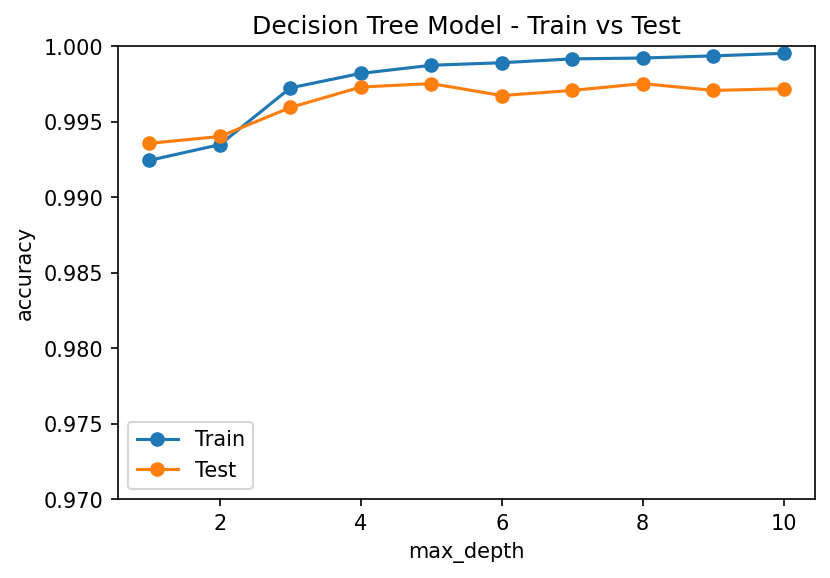

```python
# plot of train and test scores vs tree depth
mpl.rcParams["figure.dpi"] = 150

pyplot.plot(values, train_scores, '-o', label='Train')
pyplot.plot(values, test_scores, '-o', label='Test')
pyplot.xlabel("max_depth")
pyplot.ylabel("accuracy")
pyplot.yticks(np.arange(0.97, 1, step=0.005))
pyplot.title("Decision Tree Model - Train vs Test")
pyplot.legend()
pyplot.show()
```

```python
clf_DT = DecisionTreeClassifier(max_depth=8, random_state=42).fit(train_vec_tt, news_train["isTrue"])

pred_dt_train = clf_DT.predict(train_vec_tt)
pred_dt_test = clf_DT.predict(test_vec_tt)

acc_train_dt = clf_DT.score(train_vec_tt, news_train["isTrue"])
acc_test_dt = clf_DT.score(test_vec_tt, news_test["isTrue"])

print("Training data accuracy: ", acc_train_dt)
print("Test data accuracy: ", acc_test_dt)
```

```
Training data accuracy:  0.9992093075793517
Test data accuracy:  0.9975152473458324
```

```python
print(classification_report(news_test.isTrue, pred_dt_test, digits=4))
```

```
              precision    recall  f1-score   support

           0     0.9976    0.9976    0.9976      4567
           1     0.9974    0.9974    0.9974      4287

    accuracy                         0.9975      8854
   macro avg     0.9975    0.9975    0.9975      8854
weighted avg     0.9975    0.9975    0.9975      8854
```

### Neural Network Model

Check if there's overfitting issue on the test set comparing to training data results, using MLPClassifier from Sklearn

```python
train_scores_MLP, test_scores_MLP = list(), list()
# define the tree depths to evaluate
hls = [(1,), (2,), (3,), (1, 1), (2, 2), (3, 3)]
# evaluate a decision tree for each depth
for i in hls:
    # configure the model
    model = MLPClassifier(activation="tanh", solver="adam", hidden_layer_sizes=i, random_state=42, max_iter=10000)
    # fit model on the training dataset
    model.fit(train_vec_tt, news_train["isTrue"])
    # evaluate on the train dataset
    train_yhat = model.predict(train_vec_tt)
    train_acc = accuracy_score(news_train["isTrue"], train_yhat)
    train_scores_MLP.append(train_acc)
    # evaluate on the test dataset
    test_yhat = model.predict(test_vec_tt)
    test_acc = accuracy_score(news_test["isTrue"], test_yhat)
    test_scores_MLP.append(test_acc)
    # summarize progress
    print('>%s, train: %.3f, test: %.3f' % (i, train_acc, test_acc))
```

```
>(1,), train: 1.000, test: 0.999
>(2,), train: 1.000, test: 0.999
>(3,), train: 1.000, test: 0.999
>(1, 1), train: 1.000, test: 0.999
>(2, 2), train: 1.000, test: 0.999
>(3, 3), train: 1.000, test: 1.000
```

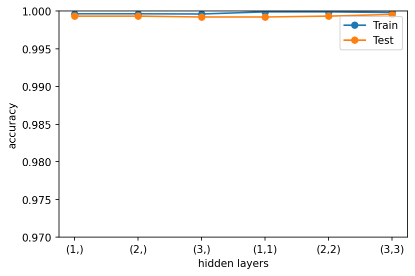

```python
# plot of train and test scores vs mlp
hls_list = ["(1,)", "(2,)", "(3,)", "(1,1)", "(2,2)", "(3,3)"]
pyplot.plot(hls_list, train_scores_MLP, '-o', label='Train')
pyplot.plot(hls_list, test_scores_MLP, '-o', label='Test')
pyplot.xlabel("hidden layers")
pyplot.ylabel("accuracy")
pyplot.title("")
pyplot.yticks(np.arange(0.97, 1, step=0.005))
pyplot.legend()
pyplot.show()
```

```python
clf_MLP = MLPClassifier(
    activation="tanh",
    solver="adam",
    alpha=0.01,
    hidden_layer_sizes=(2,2),
    random_state=42,
    max_iter=10000,
).fit(train_vec_tt, news_train["isTrue"])
```

```python
pred_train_MLP = clf_MLP.predict(train_vec_tt)
pred_test_MLP = clf_MLP.predict(test_vec_tt)

acc_train_MLP = clf_MLP.score(train_vec_tt, news_train["isTrue"])
acc_test_MLP = clf_MLP.score(test_vec_tt, news_test["isTrue"])

print("Training data accuracy: ", acc_train_MLP)
print("Test data accuracy: ", acc_test_MLP)
```

```
Training data accuracy:  0.9999435219699537
Test data accuracy:  0.9996611700926135
```

```python
print(classification_report(news_test.isTrue, pred_test_MLP, digits=4))
```

```
              precision    recall  f1-score   support

           0     0.9993    1.0000    0.9997      4567
           1     1.0000    0.9993    0.9996      4287

    accuracy                         0.9997      8854
   macro avg     0.9997    0.9997    0.9997      8854
weighted avg     0.9997    0.9997    0.9997      8854
```

### Regression Model - Title+Text (CBOW)

Create a 100-dimensional Word2vec embedding model with the **CBOW** training algorithm

```python
# get embedding weights vectors
cbow_embedding_weights_title = get_embeddings(inp_data_title, vocabulary_inv_title, mode='cbow')
cbow_embedding_weights_text = get_embeddings(inp_data_text, vocabulary_inv_text, mode='cbow')

# get training and test vectors for title and text
cbow_train_vec_title = []
for doc in tagged_train_data_title:
    vec = 0
    length = 0
    for w in doc:
        try:
            vec += cbow_embedding_weights_title[vocabulary_title[w]]
            length += 1
        except:
            continue
    vec = vec / len(doc)
    cbow_train_vec_title.append(vec)

cbow_test_vec_title = []
for doc in tagged_test_data_title:
    vec = 0
    length = 0
    for w in doc:
        try:
            vec += cbow_embedding_weights_title[vocabulary_title[w]]
            length += 1
        except:
            continue
    vec = vec / length
    cbow_test_vec_title.append(vec)

cbow_train_vec_text = []
for doc in tagged_train_data_text:
    vec = 0
    length = 0
    for w in doc:
        try:
            vec += cbow_embedding_weights_text[vocabulary_text[w]]
            length += 1
        except:
            continue
    vec = vec / len(doc)
    cbow_train_vec_text.append(vec)

cbow_test_vec_text = []
for doc in tagged_test_data_text:
    vec = 0
    length = 0
    for w in doc:
        try:
            vec += cbow_embedding_weights_text[vocabulary_text[w]]
            length += 1
        except:
            continue
    vec = vec / length
    cbow_test_vec_text.append(vec)

cbow_train_vec_tt = np.concatenate((cbow_train_vec_title, cbow_train_vec_text), axis = 1)
cbow_test_vec_tt = np.concatenate((cbow_test_vec_title, cbow_test_vec_text), axis = 1)
```

```
Training Word2Vec model...
Model: CBOW
Saving Word2Vec model embedding
```

```
Training Word2Vec model...
Model: CBOW
Saving Word2Vec model embedding
```

```python
cbow_clf_tt = LogisticRegressionCV(max_iter=100000000, cv = 5, scoring = 'accuracy', random_state = 42).fit(cbow_train_vec_tt, news_train["isTrue"])

cbow_pred_tt_train = cbow_clf_tt.predict(cbow_train_vec_tt)
cbow_pred_tt_test = cbow_clf_tt.predict(cbow_test_vec_tt)

cbow_acc_train_tt = cbow_clf_tt.score(cbow_train_vec_tt, news_train["isTrue"])
cbow_acc_test_tt = cbow_clf_tt.score(cbow_test_vec_tt, news_test["isTrue"])

print("Training data accuracy: ", cbow_acc_train_tt)
print("Test data accuracy: ", cbow_acc_test_tt)
```

```
Training data accuracy:  0.9998588049248842
Test data accuracy:  0.9995482267901513
```

```python
print(classification_report(news_test.isTrue, cbow_pred_tt_test, digits=4))
```

```
              precision    recall  f1-score   support

           0     0.9993    0.9998    0.9996      4567
           1     0.9998    0.9993    0.9995      4287

    accuracy                         0.9995      8854
   macro avg     0.9996    0.9995    0.9995      8854
weighted avg     0.9995    0.9995    0.9995      8854
```

### Test Performance using Dataset from Kaggle

```python
kaggle_df = pd.read_csv('kaggle_dataset.csv')
kaggle_df.head()
```

|  | Unnamed: 0 | title | text | label |
| --- | --- | --- | --- | --- |
| 0 | 8476 | You Can Smell Hillary’s Fear | Daniel Greenfield, a Shillman Journalism Fello... | FAKE |
| 1 | 10294 | Watch The Exact Moment Paul Ryan Committed Pol... | Google Pinterest Digg Linkedin Reddit Stumbleu... | FAKE |
| 2 | 3608 | Kerry to go to Paris in gesture of sympathy | U.S. Secretary of State John F. Kerry said Mon... | REAL |
| 3 | 10142 | Bernie supporters on Twitter erupt in anger ag... | — Kaydee King (@KaydeeKing) November 9, 2016 T... | FAKE |
| 4 | 875 | The Battle of New York: Why This Primary Matters | It's primary day in New York and front-runners... | REAL |

Drop rows that have empty title or text

```python
kaggle_df = kaggle_df.drop(3456).reset_index(drop=True)
empty_index = kaggle_df[(kaggle_df.text == ' ') | (kaggle_df.text == '  ')].index
kaggle_df = kaggle_df.drop(empty_index).reset_index(drop=True)
```

```python
print("Number of rows: ", len(kaggle_df))
```

```
Number of rows:  6298
```

```python
kaggle_df["isTrue"] = kaggle_df["label"].apply(lambda x: 0 if x == 'FAKE' else 1)
```

```python
kaggle_df["title_token"] = kaggle_df["title"]
kaggle_df = preprocess_df(kaggle_df, "title_token")

kaggle_df["text_token"] = kaggle_df["text"]
kaggle_df = preprocess_df(kaggle_df, "text_token")

kaggle_df.head()
```

|  | Unnamed: 0 | title | text | label | isTrue | title_token | text_token |
| --- | --- | --- | --- | --- | --- | --- | --- |
| 0 | 8476 | You Can Smell Hillary’s Fear | Daniel Greenfield, a Shillman Journalism Fello... | FAKE | 0 | You Can Smell Hillary’s Fear | Daniel Greenfield Shillman Journalism Fellow F... |
| 1 | 10294 | Watch The Exact Moment Paul Ryan Committed Pol... | Google Pinterest Digg Linkedin Reddit Stumbleu... | FAKE | 0 | Watch The Exact Moment Paul Ryan Committed Pol... | Google Pinterest Digg Linkedin Reddit Stumbleu... |
| 2 | 3608 | Kerry to go to Paris in gesture of sympathy | U.S. Secretary of State John F. Kerry said Mon... | REAL | 1 | Kerry go Paris gesture sympathy | Secretary State John Kerry said Monday stop Pa... |
| 3 | 10142 | Bernie supporters on Twitter erupt in anger ag... | — Kaydee King (@KaydeeKing) November 9, 2016 T... | FAKE | 0 | Bernie supporters Twitter erupt anger DNC We t... | Kaydee King KaydeeKing November 2016 The lesso... |
| 4 | 875 | The Battle of New York: Why This Primary Matters | It's primary day in New York and front-runners... | REAL | 1 | The Battle New York Why This Primary Matters | It primary day New York front runners Hillary ... |

```python
tagged_data_title_kaggle = [word_tokenize(_d) for i, _d in enumerate(kaggle_df["title_token"])]
word_counts_title_kaggle, vocabulary_title_kaggle, vocabulary_inv_title_kaggle = build_vocab(tagged_data_title_kaggle)
inp_data_title_kaggle = [[vocabulary_title_kaggle[word] for word in title] for title in tagged_data_title_kaggle]

# get embedding vector for titles
embedding_weights_title_kaggle = get_embeddings(inp_data_title_kaggle, vocabulary_inv_title_kaggle, mode='skipgram')
```

```
Training Word2Vec model...
Model: skip-gram
Saving Word2Vec model embedding
```

```python
tagged_data_text_kaggle = [word_tokenize(_d) for i, _d in enumerate(kaggle_df["text_token"])]
word_counts_text_kaggle, vocabulary_text_kaggle, vocabulary_inv_text_kaggle = build_vocab(tagged_data_text_kaggle)
inp_data_text_kaggle = [[vocabulary_text_kaggle[word] for word in text] for text in tagged_data_text_kaggle]

# get embedding vector
embedding_weights_text_kaggle = get_embeddings(inp_data_text_kaggle, vocabulary_inv_text_kaggle, mode='skipgram')
```

```
Training Word2Vec model...
Model: skip-gram
Saving Word2Vec model embedding
```

```python
# get vectors for title and text
vec_title_kaggle = []
for doc in tagged_data_title_kaggle:
    vec = 0
    length = 0
    for w in doc:
        try:
            vec += embedding_weights_title_kaggle[vocabulary_title_kaggle[w]]
            length += 1
        except:
            continue
    vec = vec / len(doc)
    vec_title_kaggle.append(vec)

vec_text_kaggle = []
for doc in tagged_data_text_kaggle:
    vec = 0
    length = 0
    for w in doc:
        try:
            vec += embedding_weights_text_kaggle[vocabulary_text_kaggle[w]]
            length += 1
        except:
            continue
    vec = vec / length
    vec_text_kaggle.append(vec)

vec_tt_kaggle = np.concatenate((vec_title_kaggle, vec_text_kaggle), axis = 1)
```

```python
clf_tt_kaggle = LogisticRegressionCV(max_iter=100000000, cv = 5, scoring = 'accuracy', random_state = 42).fit(vec_tt_kaggle, kaggle_df["isTrue"])
pred_tt_kaggle = clf_tt_kaggle.predict(vec_tt_kaggle)
acc_tt_kaggle = clf_tt_kaggle.score(vec_tt_kaggle, kaggle_df["isTrue"])

print("Kaggle data accuracy: ", acc_tt_kaggle)
```

```
Kaggle data accuracy:  0.9374404572880279
```

```python
print(classification_report(kaggle_df.isTrue, pred_tt_kaggle, digits=4))
```

```
              precision    recall  f1-score   support

           0     0.9370    0.9370    0.9370      3127
           1     0.9379    0.9379    0.9379      3171

    accuracy                         0.9374      6298
   macro avg     0.9374    0.9374    0.9374      6298
weighted avg     0.9374    0.9374    0.9374      6298
```

```python
clf_tt_kaggle_nn = MLPClassifier(
    activation="tanh",
    solver="adam",
    alpha=0.01,
    hidden_layer_sizes=(2,2),
    random_state=42,
    max_iter=10000,
).fit(vec_tt_kaggle, kaggle_df["isTrue"])
```

```python
pred_tt_kaggle_nn = clf_tt_kaggle_nn.predict(vec_tt_kaggle)
acc_tt_kaggle_nn = clf_tt_kaggle_nn.score(vec_tt_kaggle, kaggle_df["isTrue"])

print("Kaggle data accuracy: ", acc_tt_kaggle_nn)
```

```
Kaggle data accuracy:  0.9345824071133694
```

```python
print(classification_report(kaggle_df.isTrue, pred_tt_kaggle_nn, digits=4))
```

```
              precision    recall  f1-score   support

           0     0.9452    0.9217    0.9333      3127
           1     0.9246    0.9473    0.9358      3171

    accuracy                         0.9346      6298
   macro avg     0.9349    0.9345    0.9346      6298
weighted avg     0.9348    0.9346    0.9346      6298
```

### Final Model Comparison

Create a table including dataset, classifier, features, accuracy

```python
pred_model = pd.DataFrame(
    {
        "Dataset": ["ISOT", "ISOT", "ISOT", "ISOT", "ISOT", "ISOT", "Kaggle", "Kaggle"],
        "Embedding Method": ["skip-gram", "skip-gram", "skip-gram", "skip-gram", "skip-gram", "CBOW", "skip-gram", "skip-gram"],
        "Classifier": ["Logistic Regression CV", "Logistic Regression CV", "Logistic Regression CV", "Decision Tree", "Neural Network MLP", "Logistic Regression CV", "Logistic Regression CV", "Neural Network MLP"],
        "Features": ["title", "text", "title,text", "title,text", "title,text", "title,text", "title,text", "title,text"],
        "Accuracy": [acc_test_title, acc_test_text, acc_test_tt, acc_test_dt, acc_test_MLP, cbow_acc_test_tt, acc_tt_kaggle, acc_tt_kaggle_nn]
    }
)
pred_model
```

|  | Dataset | Embedding Method | Classifier | Features | Accuracy |
| --- | --- | --- | --- | --- | --- |
| 0 | ISOT | skip-gram | Logistic Regression CV | title | 0.997854 |
| 1 | ISOT | skip-gram | Logistic Regression CV | text | 0.989496 |
| 2 | ISOT | skip-gram | Logistic Regression CV | title,text | 0.999661 |
| 3 | ISOT | skip-gram | Decision Tree | title,text | 0.997515 |
| 4 | ISOT | skip-gram | Neural Network MLP | title,text | 0.999661 |
| 5 | ISOT | CBOW | Logistic Regression CV | title,text | 0.999548 |
| 6 | Kaggle | skip-gram | Logistic Regression CV | title,text | 0.937440 |
| 7 | Kaggle | skip-gram | Neural Network MLP | title,text | 0.934582 |

### Text Analysis

For text analysis, we treat the same words but with lower letters or capital letters as different words, such as "Trump" and "TRUMP", since capital letters in the title(or text) has a more exaggerated meaning and may be a way the model defines whether it's a fake news or not. Same concept was done in the entire analysis.

```python
word_counts_title_df = pd.DataFrame.from_dict(word_counts_title, orient='index').reset_index()
word_counts_title_df = word_counts_title_df.rename(columns={'index':'words', 0:'count'}).sort_values("count", ascending=False).reset_index(drop=True)

stop_words = set(stopwords.words('english'))

index_stopwords = []
for i in range(len(word_counts_title_df)):
    if word_counts_title_df.iloc[i, 0].lower() in stop_words or len(word_counts_title_df.iloc[i, 0])==1:
        index_stopwords.append(i)

#index_stopwords
word_counts_title_df = word_counts_title_df.drop(index_stopwords).reset_index(drop=True)
word_counts_title_df.head(20)
```

|  | words | count |
| --- | --- | --- |
| 0 | Trump | 10708 |
| 1 | VIDEO | 4262 |
| 2 | says | 2382 |
| 3 | Video | 2117 |
| 4 | Obama | 1798 |
| 5 | House | 1481 |
| 6 | WATCH | 1238 |
| 7 | Hillary | 1221 |
| 8 | White | 1208 |
| 9 | Clinton | 1123 |
| 10 | Russia | 1069 |
| 11 | Republican | 822 |
| 12 | TRUMP | 809 |
| 13 | North | 792 |
| 14 | President | 790 |
| 15 | New | 773 |
| 16 | Korea | 760 |
| 17 | Senate | 736 |
| 18 | BREAKING | 685 |
| 19 | OBAMA | 666 |

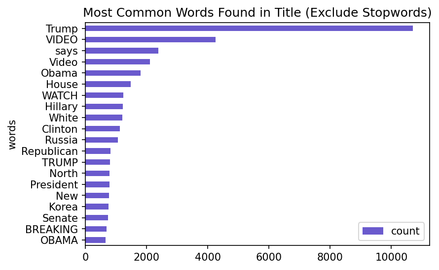

```python
# Plot horizontal bar graph
mpl.rcParams["figure.dpi"] = 150
fig, ax = plt.subplots(figsize=(6, 4))
word_counts_title_df.head(20).sort_values(by='count').plot.barh(x='words', y='count', ax=ax, color="slateblue")
ax.set_title("Most Common Words Found in Title (Exclude Stopwords)")
plt.show()
```

```python
word_counts_text_df = pd.DataFrame.from_dict(word_counts_text, orient='index').reset_index()
word_counts_text_df = word_counts_text_df.rename(columns={'index':'words', 0:'count'}).sort_values("count", ascending=False).reset_index(drop=True)

stop_words = set(stopwords.words('english'))

index_stopwords = []
for i in range(len(word_counts_text_df)):
    if word_counts_text_df.iloc[i, 0].lower() in stop_words or len(word_counts_text_df.iloc[i, 0])==1:
        index_stopwords.append(i)

#index_stopwords
word_counts_text_df = word_counts_text_df.drop(index_stopwords).reset_index(drop=True)
word_counts_text_df.head(20)
```

|  | words | count |
| --- | --- | --- |
| 0 | said | 106510 |
| 1 | Trump | 106044 |
| 2 | would | 44001 |
| 3 | people | 31814 |
| 4 | President | 28886 |
| 5 | one | 26090 |
| 6 | also | 24368 |
| 7 | Reuters | 23476 |
| 8 | Clinton | 22957 |
| 9 | Obama | 22374 |
| 10 | Donald | 22333 |
| 11 | government | 21424 |
| 12 | House | 20375 |
| 13 | Republican | 20345 |
| 14 | year | 19590 |
| 15 | could | 18917 |
| 16 | told | 18721 |
| 17 | United | 18270 |
| 18 | like | 17480 |
| 19 | campaign | 17022 |

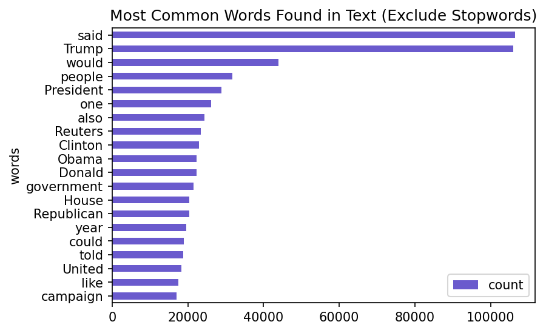

```python
fig, ax = plt.subplots(figsize=(6, 4))
word_counts_text_df.head(20).sort_values(by='count').plot.barh(x='words', y='count', ax=ax, color="slateblue")
ax.set_title("Most Common Words Found in Text (Exclude Stopwords)")
plt.show()
```

Next we can use Word Cloud to see more clearly on the title and text, and differentiate by fake and true news.

Create a word cloud from the title for "fake" news

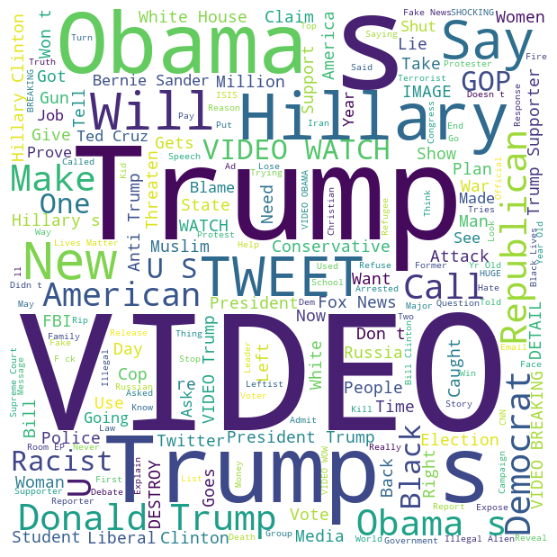

```python
stopwords = set(STOPWORDS)
fake_title_words = ''

for doc in news.query("isTrue == 0").title:
    tokens = doc.split()
    fake_title_words += " ".join(tokens)

wordcloud = WordCloud(width = 600, height = 600, background_color ='white', stopwords = stopwords, min_font_size = 10, random_state = 42).generate(fake_title_words)

# plot the WordCloud image
mpl.rcParams["figure.dpi"] = 100
plt.figure(figsize = (6, 6), facecolor = None)
plt.imshow(wordcloud)
plt.axis("off")
plt.tight_layout(pad = 0)
plt.show()
```

Create a word cloud from the title for "true" news

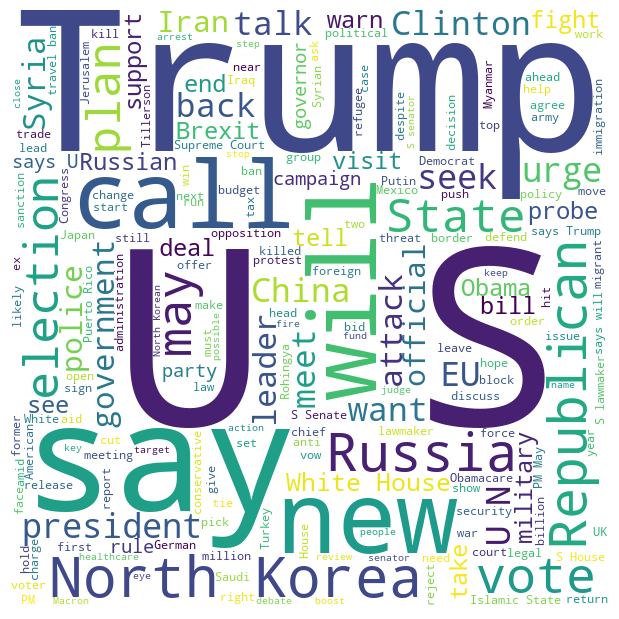

```python
true_title_words = ''

for doc in news.query("isTrue == 1").title:
    tokens = doc.split()
    true_title_words += " ".join(tokens)

wordcloud = WordCloud(width = 600, height = 600, background_color ='white', stopwords = stopwords, min_font_size = 10, random_state = 42).generate(true_title_words)

# plot the WordCloud image
plt.figure(figsize = (6, 6), facecolor = None)
plt.imshow(wordcloud)
plt.axis("off")
plt.tight_layout(pad = 0)
plt.show()
```

Create a word cloud from the text for "fake" news

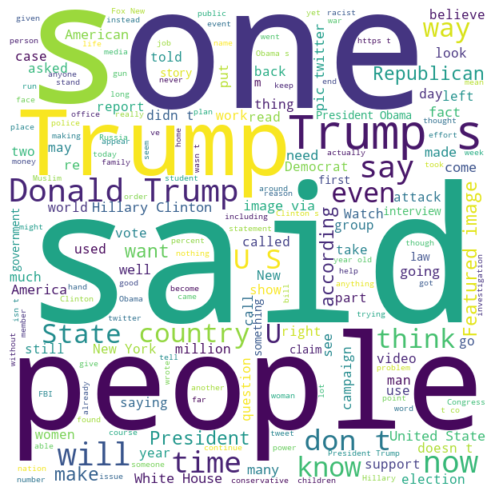

```python
fake_text_words = ''

for doc in news.query("isTrue == 0").text:
    tokens = doc.split()
    fake_text_words += " ".join(tokens)

wordcloud = WordCloud(width = 600, height = 600, background_color ='white', stopwords = stopwords, min_font_size = 10).generate(fake_text_words)

# plot the WordCloud image
plt.figure(figsize = (6, 6), facecolor = None)
plt.imshow(wordcloud)
plt.axis("off")
plt.tight_layout(pad = 0)
plt.show()
```

Create a word cloud from the text for "true" news

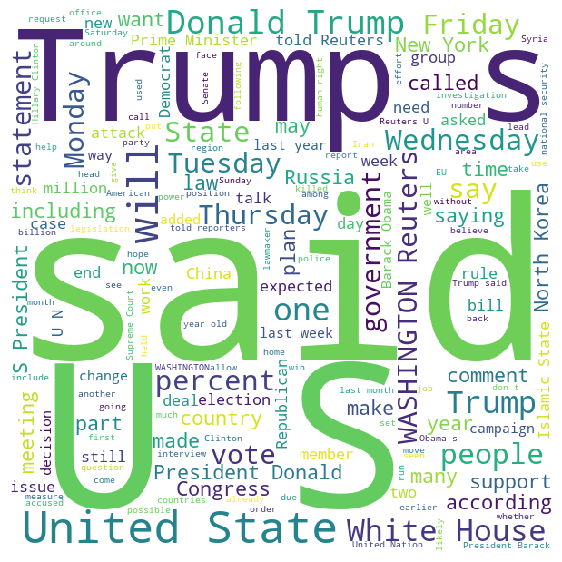

```python
true_text_words = ''

for doc in news.query("isTrue == 1").text:
    tokens = doc.split()
    true_text_words += " ".join(tokens)

wordcloud = WordCloud(width = 600, height = 600, background_color ='white', stopwords = stopwords, min_font_size = 10).generate(true_text_words)

# plot the WordCloud image
plt.figure(figsize = (6, 6), facecolor = None)
plt.imshow(wordcloud)
plt.axis("off")
plt.tight_layout(pad = 0)
plt.show()
```